# Codebook

### Metadata

#### Description

**Dataset name**: The Power of Conformity in Citizens’ Blame

Data set for Sievert, M., Vogel, D., Reinders, T., & Ahmed, W.. (2019). The Power of Conformity in Citizens’ Blame: Evidence from a Survey Experiment. Public Performance & Management Review.

**Metadata for search engines**

- **Temporal Coverage**: April 2017
- **Spatial Coverage**: Hamburg, Germany
- **Citation**: Sievert, M., Vogel, D., Reinders, T., & Ahmed, W. (2019). The Power of Conformity in Citizens’ Blame: Evidence from a Survey Experiment. Public Performance & Management Review.
- **URL**:
- **Identifier**: https://doi.org/10.7910/DVN/KYOABG
- **Date published**: 2019-06-21
- **Creator**:Martin Sievert, Dominik Vogel, Tim Reinders, Waqar Ahmed
  - **keywords**: *quality_time_management*, *quality_service_on_time*, *quality_amount_of_staff*, *quality_overall*, *attention_check*, *blame_responsible*, *blame_fault*, *blame_time_management*, *blame_substantial_service*, *blame_employees*, *blame_overall*, *blame_willing*, *political_orientation*, *visit_service_center*, *yearbirth*, *gender* and *group*

## Variables

### quality_time_management

time management regarding the appointments for citizens?

#### Distribution

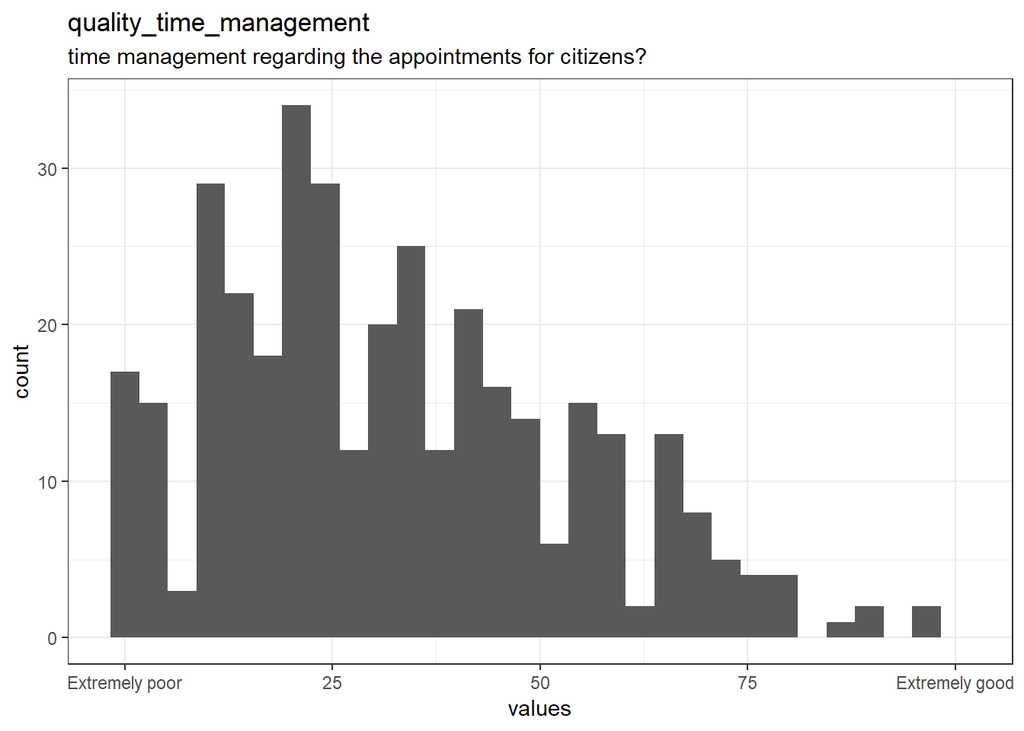

0 missing values.

#### Summary statistics

| name | label | data_type | value_labels | missing | complete | n | mean | sd | p0 | p25 | p50 | p75 | p100 | hist |
| --- | --- | --- | --- | --- | --- | --- | --- | --- | --- | --- | --- | --- | --- | --- |
| quality_time_management | time management regarding the appointments for citizens? | numeric | 0. Extremely poor, 100. Extremely good | 0 | 362 | 362 | 32.62 | 21.12 | 0 | 16 | 30 | 46 | 97 | ▆▇▇▅▅▂▁▁ |

#### Value labels

- **Extremely poor**: *0*
- **Extremely good**: *100*

### quality_service_on_time

certainty that citizens receive substantial service on time?

#### Distribution

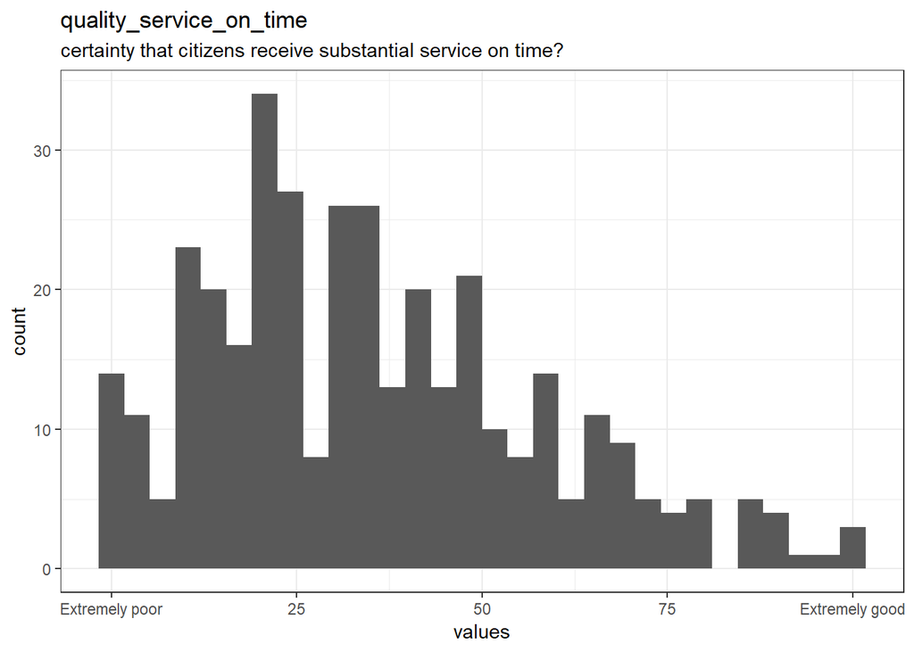

0 missing values.

#### Summary statistics

| name | label | data_type | value_labels | missing | complete | n | mean | sd | p0 | p25 | p50 | p75 | p100 | hist |
| --- | --- | --- | --- | --- | --- | --- | --- | --- | --- | --- | --- | --- | --- | --- |
| quality_service_on_time | certainty that citizens receive substantial service on time? | numeric | 0. Extremely poor, 100. Extremely good | 0 | 362 | 362 | 35.5 | 22.53 | 0 | 19 | 31.5 | 50 | 100 | ▅▇▆▅▃▂▁▁ |

#### Value labels

- **Extremely poor**: *0*
- **Extremely good**: *100*

### quality_amount_of_staff

amount of staff that is working in the registration offices?

#### Distribution

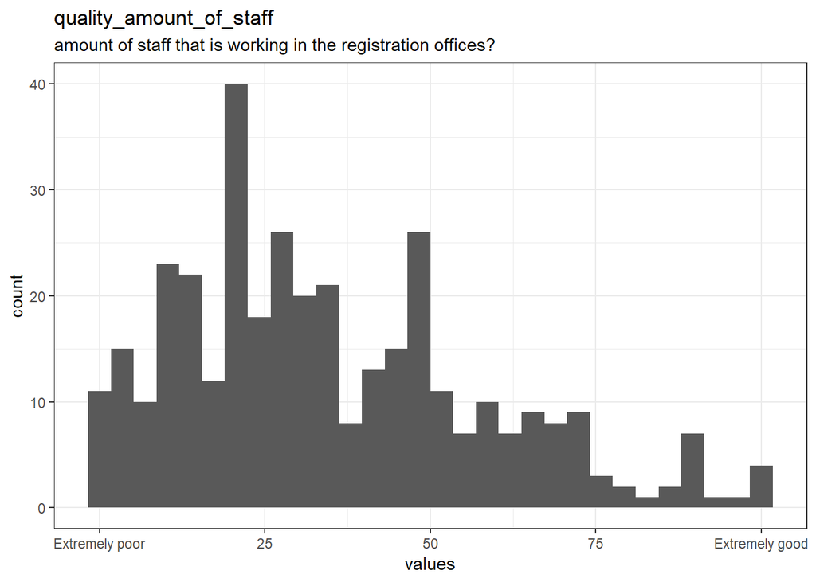

0 missing values.

#### Summary statistics

| name | label | data_type | value_labels | missing | complete | n | mean | sd | p0 | p25 | p50 | p75 | p100 | hist |
| --- | --- | --- | --- | --- | --- | --- | --- | --- | --- | --- | --- | --- | --- | --- |
| quality_amount_of_staff | amount of staff that is working in the registration offices? | numeric | 0. Extremely poor, 100. Extremely good | 0 | 362 | 362 | 34.81 | 23.07 | 0 | 17.25 | 30 | 50 | 100 | ▅▇▆▅▃▃▁▁ |

#### Value labels

- **Extremely poor**: *0*
- **Extremely good**: *100*

### quality_overall

Overall, what do you think of the quality of the waiting time for appointments in registration offices as presented before?

#### Distribution

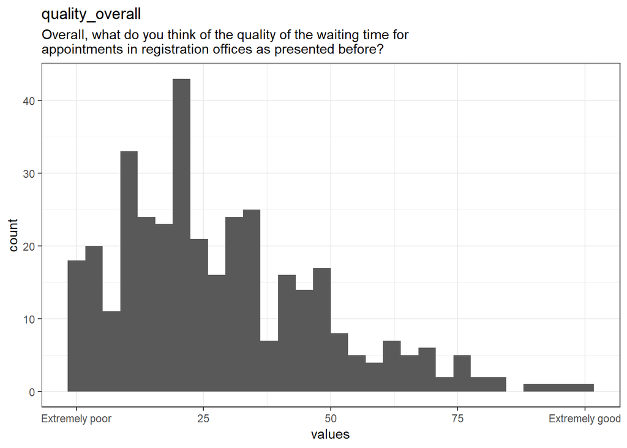

0 missing values.

#### Summary statistics

| name | label | data_type | value_labels | missing | complete | n | mean | sd | p0 | p25 | p50 | p75 | p100 | hist |
| --- | --- | --- | --- | --- | --- | --- | --- | --- | --- | --- | --- | --- | --- | --- |
| quality_overall | Overall, what do you think of the quality of the waiting time for appointments in registration offices as presented before? | numeric | 0. Extremely poor, 100. Extremely good | 0 | 362 | 362 | 28.68 | 20.26 | 0 | 14.25 | 24 | 40 | 100 | ▆▇▅▃▂▁▁▁ |

#### Value labels

- **Extremely poor**: *0*
- **Extremely good**: *100*

### attention_check

In which timeframe will you get an appointment in the registration offices in Hamburg?

#### Distribution

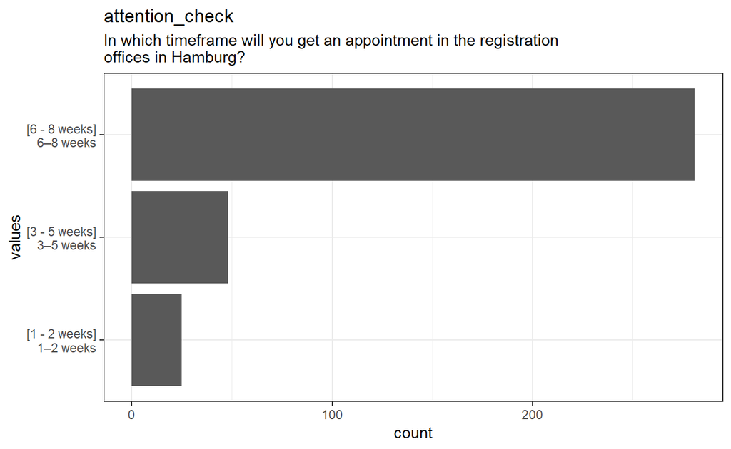

8 missing values.

#### Summary statistics

| name | label | data_type | value_labels | missing | complete | n | empty | n_unique | min | max |
| --- | --- | --- | --- | --- | --- | --- | --- | --- | --- | --- |
| attention_check | In which timeframe will you get an appointment in the registration offices in Hamburg? | character | 1 - 2 weeks. 1–2 weeks, 3 - 5 weeks. 3–5 weeks, 6 - 8 weeks. 6–8 weeks | 8 | 354 | 362 | 0 | 3 | 11 | 11 |

#### Value labels

- **1–2 weeks**: 1 - 2 weeks
- **3–5 weeks**: 3 - 5 weeks
- **6–8 weeks**: 6 - 8 weeks

### blame_responsible

How much do you think local politicians are responsible for the given situation in the registration offices?

#### Distribution

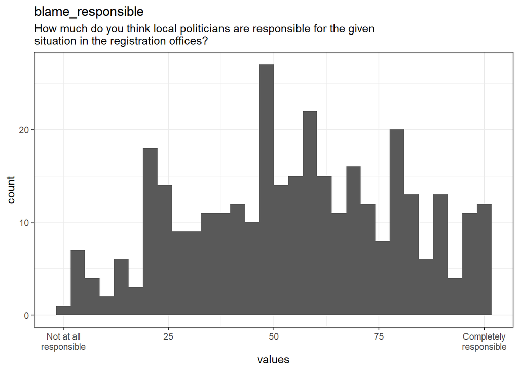

26 missing values.

#### Summary statistics

| name | label | data_type | value_labels | missing | complete | n | mean | sd | p0 | p25 | p50 | p75 | p100 | hist |
| --- | --- | --- | --- | --- | --- | --- | --- | --- | --- | --- | --- | --- | --- | --- |
| blame_responsible | How much do you think local politicians are responsible for the given situation in the registration offices? | numeric | 0. Not at all responsible, 100. Completely responsible | 26 | 336 | 362 | 55.38 | 25.17 | 1 | 36.75 | 56 | 75 | 100 | ▂▅▅▇▇▆▆▅ |

#### Value labels

- **Not at all responsible**: *0*
- **Completely responsible**: *100*

### blame_fault

How much do you think the given situation is local politician’s fault?

#### Distribution

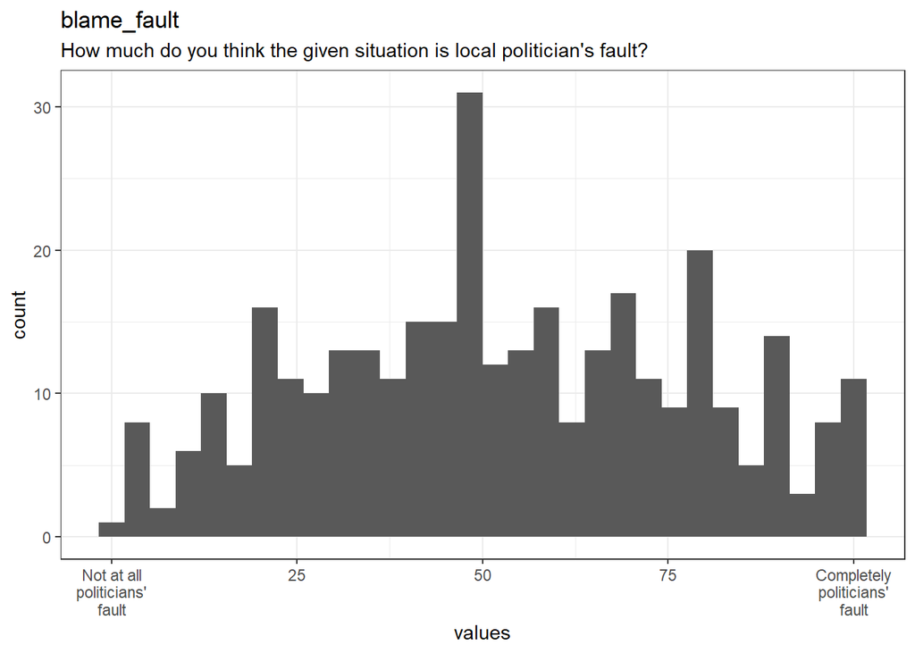

26 missing values.

#### Summary statistics

| name | label | data_type | value_labels | missing | complete | n | mean | sd | p0 | p25 | p50 | p75 | p100 | hist |
| --- | --- | --- | --- | --- | --- | --- | --- | --- | --- | --- | --- | --- | --- | --- |
| blame_fault | How much do you think the given situation is local politician’s fault? | numeric | 0. Not at all politicians’ fault, 100. Completely politicians’ fault | 26 | 336 | 362 | 52.84 | 25.24 | 1 | 33.75 | 51 | 72.25 | 100 | ▂▅▅▇▆▆▅▅ |

#### Value labels

- **Not at all politicians’ fault**: *0*
- **Completely politicians’ fault**: *100*

### blame_time_management

Time management regarding the appointments for citizens?

#### Distribution

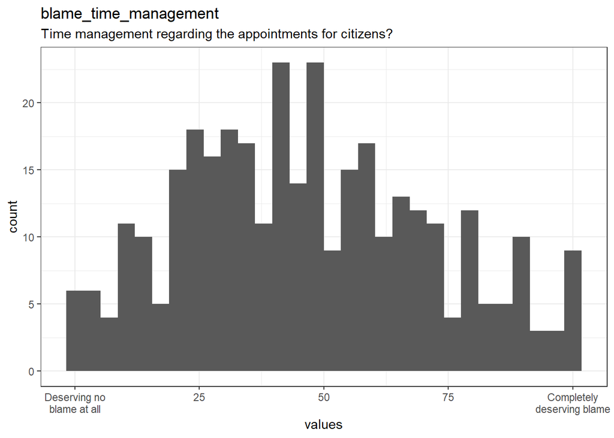

27 missing values.

#### Summary statistics

| name | label | data_type | value_labels | missing | complete | n | mean | sd | p0 | p25 | p50 | p75 | p100 | hist |
| --- | --- | --- | --- | --- | --- | --- | --- | --- | --- | --- | --- | --- | --- | --- |
| blame_time_management | Time management regarding the appointments for citizens? | numeric | 0. Deserving no blame at all, 100. Completely deserving blame | 27 | 335 | 362 | 46.88 | 24.85 | 0 | 28 | 45 | 65 | 100 | ▃▆▇▇▆▅▃▃ |

#### Value labels

- **Deserving no blame at all**: *0*
- **Completely deserving blame**: *100*

### blame_substantial_service

Certainty that citizens receive substantial service on time?

#### Distribution

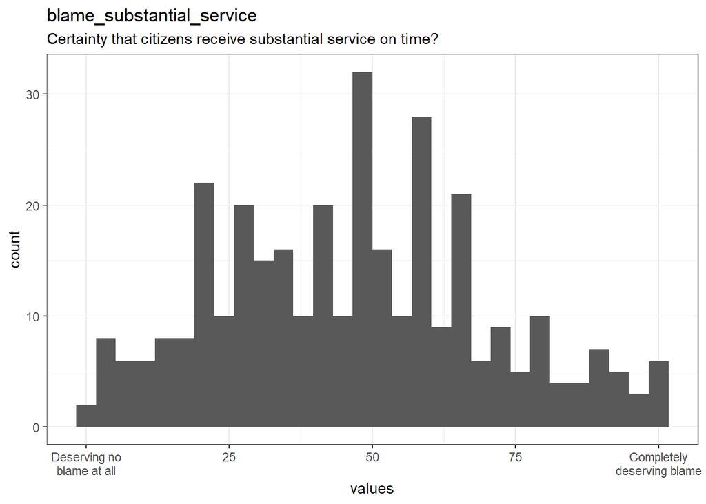

26 missing values.

#### Summary statistics

| name | label | data_type | value_labels | missing | complete | n | mean | sd | p0 | p25 | p50 | p75 | p100 | hist |
| --- | --- | --- | --- | --- | --- | --- | --- | --- | --- | --- | --- | --- | --- | --- |
| blame_substantial_service | Certainty that citizens receive substantial service on time? | numeric | 0. Deserving no blame at all, 100. Completely deserving blame | 26 | 336 | 362 | 46.82 | 23.57 | 0 | 28.75 | 48 | 62.25 | 100 | ▂▆▆▇▇▅▂▂ |

#### Value labels

- **Deserving no blame at all**: *0*
- **Completely deserving blame**: *100*

### blame_employees

Amount of employees that are working in the registration offices?

#### Distribution

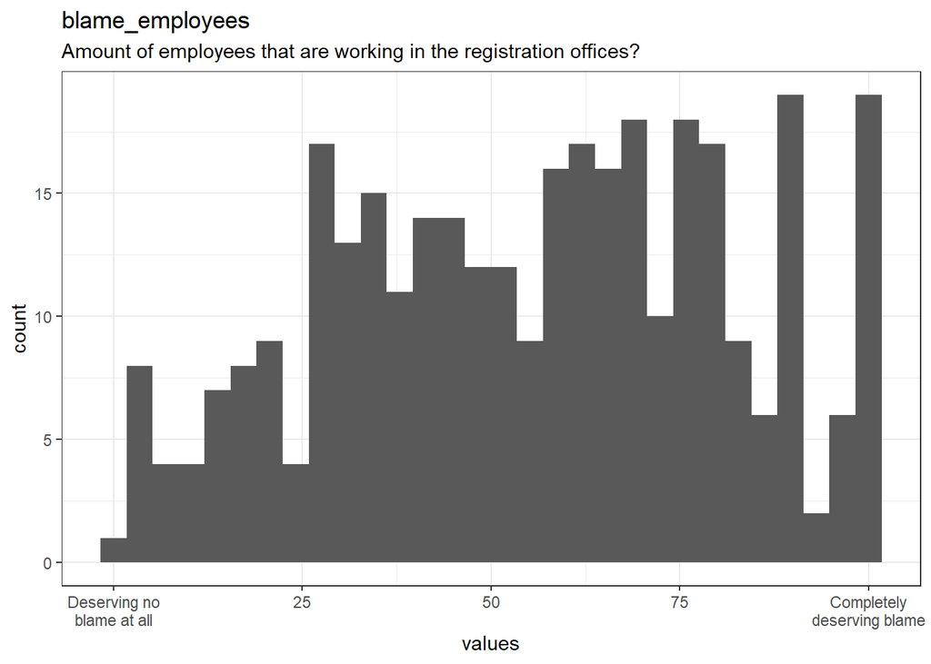

27 missing values.

#### Summary statistics

| name | label | data_type | value_labels | missing | complete | n | mean | sd | p0 | p25 | p50 | p75 | p100 | hist |
| --- | --- | --- | --- | --- | --- | --- | --- | --- | --- | --- | --- | --- | --- | --- |
| blame_employees | Amount of employees that are working in the registration offices? | numeric | 0. Deserving no blame at all, 100. Completely deserving blame | 27 | 335 | 362 | 55.79 | 26.25 | 0 | 34 | 58 | 76 | 100 | ▂▃▆▆▇▇▅▆ |

#### Value labels

- **Deserving no blame at all**: *0*
- **Completely deserving blame**: *100*

### blame_overall

Overall, to what extent do you believe local politicians are deserving blame for the waiting times as displayed to you earlier?

#### Distribution

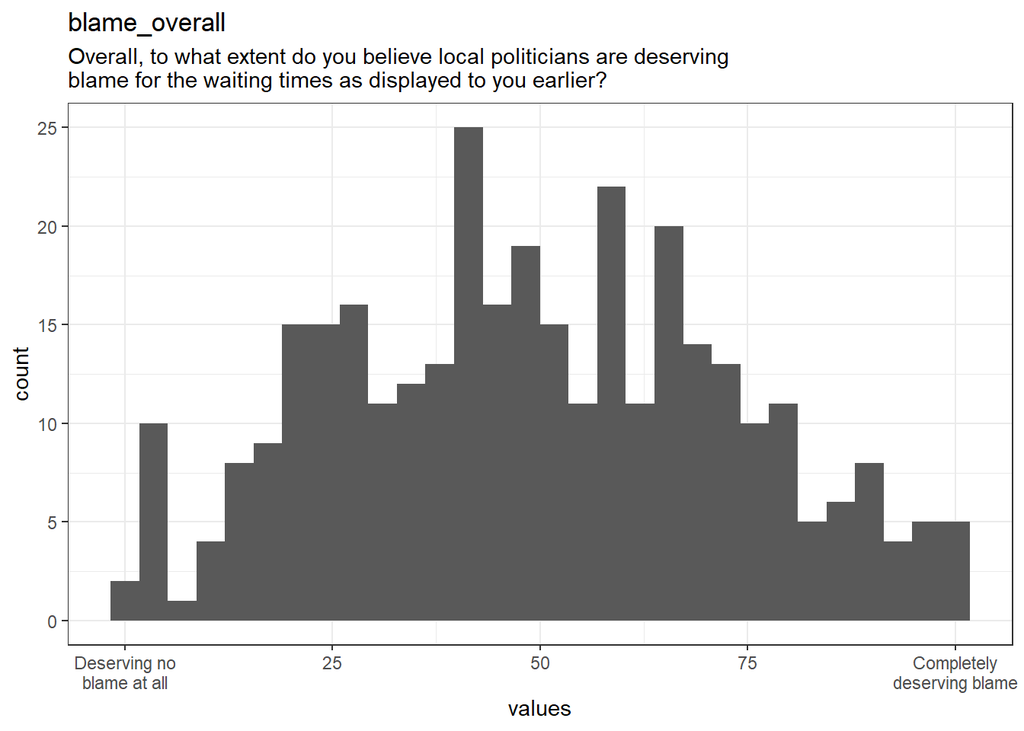

26 missing values.

#### Summary statistics

| name | label | data_type | value_labels | missing | complete | n | mean | sd | p0 | p25 | p50 | p75 | p100 | hist |
| --- | --- | --- | --- | --- | --- | --- | --- | --- | --- | --- | --- | --- | --- | --- |
| blame_overall | Overall, to what extent do you believe local politicians are deserving blame for the waiting times as displayed to you earlier? | numeric | 0. Deserving no blame at all, 100. Completely deserving blame | 26 | 336 | 362 | 49.48 | 23.81 | 0 | 30 | 50 | 67 | 100 | ▂▆▅▇▇▆▃▂ |

#### Value labels

- **Deserving no blame at all**: *0*
- **Completely deserving blame**: *100*

### blame_willing

Overall, to what extent are you willing to attribute blame to local politicians for the waiting times as displayed earlier?

#### Distribution

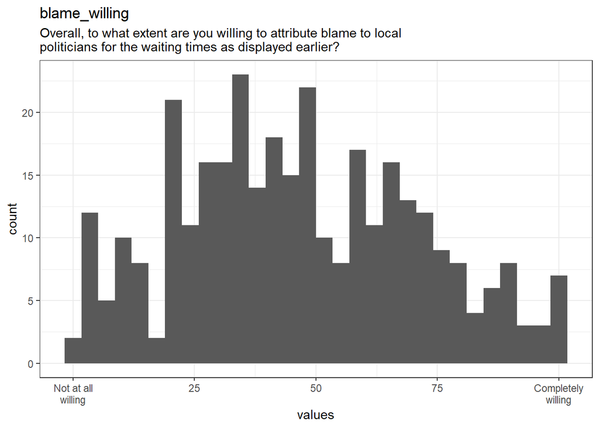

32 missing values.

#### Summary statistics

| name | label | data_type | value_labels | missing | complete | n | mean | sd | p0 | p25 | p50 | p75 | p100 | hist |
| --- | --- | --- | --- | --- | --- | --- | --- | --- | --- | --- | --- | --- | --- | --- |
| blame_willing | Overall, to what extent are you willing to attribute blame to local politicians for the waiting times as displayed earlier? | numeric | 0. Not at all willing, 100. Completely willing | 32 | 330 | 362 | 46.65 | 24.51 | 0 | 28.25 | 45 | 66 | 100 | ▃▅▇▇▅▆▂▂ |

#### Value labels

- **Not at all willing**: *0*
- **Completely willing**: *100*

### political_orientation

In politics people sometimes talk of ‘left’ and ‘right’. Where would you place yourself on a scale from 0 to 10?

#### Distribution

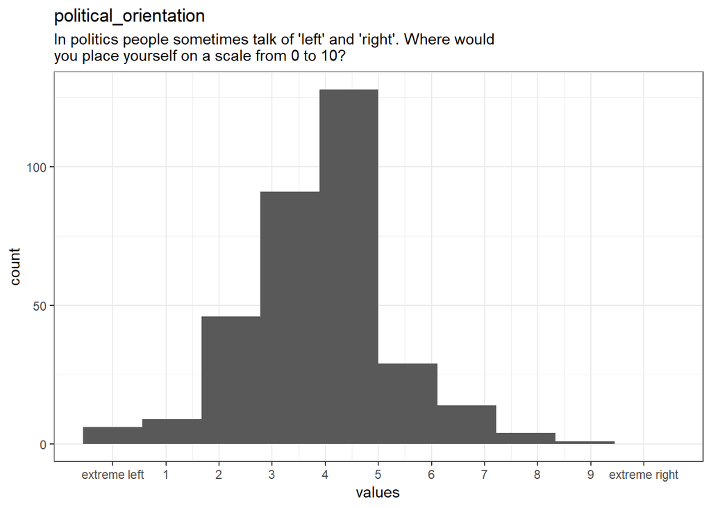

34 missing values.

#### Summary statistics

| name | label | data_type | value_labels | missing | complete | n | mean | sd | p0 | p25 | p50 | p75 | p100 | hist |
| --- | --- | --- | --- | --- | --- | --- | --- | --- | --- | --- | --- | --- | --- | --- |
| political_orientation | In politics people sometimes talk of ‘left’ and ‘right’. Where would you place yourself on a scale from 0 to 10? | numeric | 0. extreme left, 10. extreme right | 34 | 328 | 362 | 3.87 | 1.61 | 0 | 3 | 4 | 5 | 9 | ▁▅▇▅▆▂▁▁ |

#### Value labels

- **extreme left**: *0*
- **extreme right**: *10*

### visit_service_center

Did you attend a registration office in the last 12 months?

#### Distribution

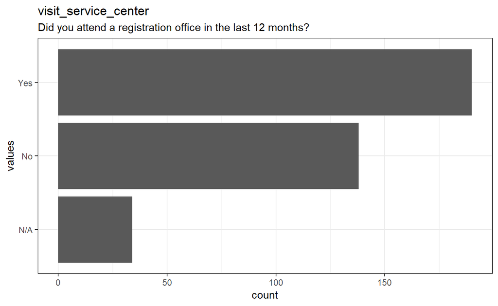

0 missing values.

#### Summary statistics

| name | label | data_type | value_labels | missing | complete | n | empty | n_unique | min | max |
| --- | --- | --- | --- | --- | --- | --- | --- | --- | --- | --- |
| visit_service_center | Did you attend a registration office in the last 12 months? | character | No. No, Yes. Yes, NA. N/A | 0 | 362 | 362 | 0 | 3 | 2 | 3 |

#### Value labels

- **No**: No
- **Yes**: Yes
- **N/A**: *NA*

### yearbirth

What year were you born?

#### Distribution

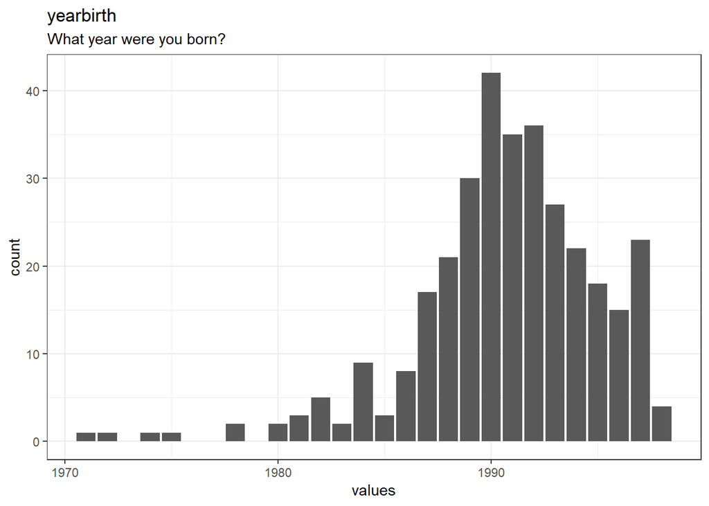

34 missing values.

#### Summary statistics

| name | label | data_type | missing | complete | n | mean | sd | p0 | p25 | p50 | p75 | p100 | hist |
| --- | --- | --- | --- | --- | --- | --- | --- | --- | --- | --- | --- | --- | --- |
| yearbirth | What year were you born? | numeric | 34 | 328 | 362 | 1990.71 | 4.32 | 1971 | 1989 | 1991 | 1993.25 | 1998 | ▁▁▁▁▂▇▅▃ |

### gender

How do you describe your gender identity?

#### Distribution

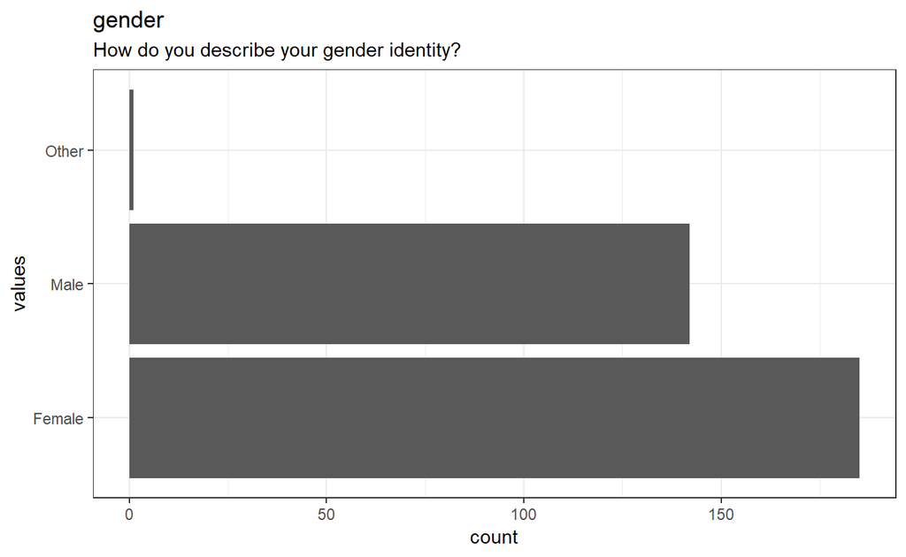

34 missing values.

#### Summary statistics

| name | label | data_type | value_labels | missing | complete | n | empty | n_unique | min | max |
| --- | --- | --- | --- | --- | --- | --- | --- | --- | --- | --- |
| gender | How do you describe your gender identity? | character | Male. Male, Female. Female | 34 | 328 | 362 | 0 | 3 | 4 | 6 |

#### Value labels

- **Male**: Male
- **Female**: Female

### group

Treatment group

#### Distribution

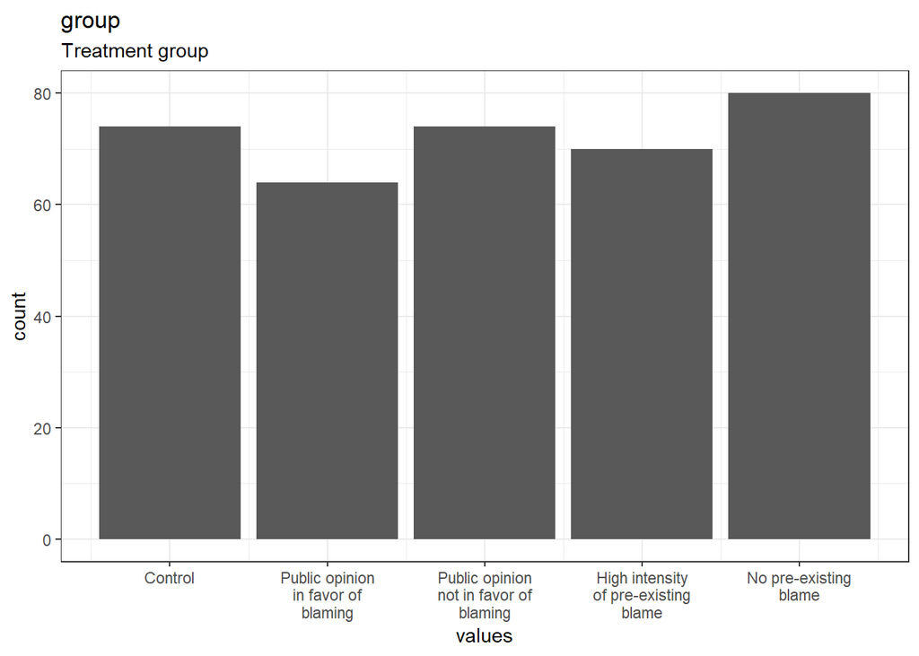

0 missing values.

#### Summary statistics

| name | label | data_type | value_labels | missing | complete | n | mean | sd | p0 | p25 | p50 | p75 | p100 | hist |
| --- | --- | --- | --- | --- | --- | --- | --- | --- | --- | --- | --- | --- | --- | --- |
| group | Treatment group | numeric | 0. Control, 1. Public opinion in favor of blaming, 2. Public opinion not in favor of blaming, 3. High intensity of pre-existing blame, 4. No pre-existing blame | 0 | 362 | 362 | 2.05 | 1.44 | 0 | 1 | 2 | 3 | 4 | ▇▆▁▇▁▇▁▇ |

#### Value labels

- **Control**: *0*
- **Public opinion in favor of blaming**: *1*
- **Public opinion not in favor of blaming**: *2*
- **High intensity of pre-existing blame**: *3*
- **No pre-existing blame**: *4*

## Codebook table

| name | label | data_type | value_labels | missing | complete | n | empty | n_unique | min | max | mean | sd | p0 | p25 | p50 | p75 | p100 | hist |
| --- | --- | --- | --- | --- | --- | --- | --- | --- | --- | --- | --- | --- | --- | --- | --- | --- | --- | --- |
| quality_time_management | time management regarding the appointments for citizens? | numeric | 0. Extremely poor,100. Extremely good | 0 | 362 | 362 |  |  |  |  | 32.62 | 21.12 | 0 | 16 | 30 | 46 | 97 | ▆▇▇▅▅▂▁▁ |
| quality_service_on_time | certainty that citizens receive substantial service on time? | numeric | 0. Extremely poor,100. Extremely good | 0 | 362 | 362 |  |  |  |  | 35.5 | 22.53 | 0 | 19 | 31.5 | 50 | 100 | ▅▇▆▅▃▂▁▁ |
| quality_amount_of_staff | amount of staff that is working in the registration offices? | numeric | 0. Extremely poor,100. Extremely good | 0 | 362 | 362 |  |  |  |  | 34.81 | 23.07 | 0 | 17.25 | 30 | 50 | 100 | ▅▇▆▅▃▃▁▁ |
| quality_overall | Overall, what do you think of the quality of the waiting time for appointments in registration offices as presented before? | numeric | 0. Extremely poor,100. Extremely good | 0 | 362 | 362 |  |  |  |  | 28.68 | 20.26 | 0 | 14.25 | 24 | 40 | 100 | ▆▇▅▃▂▁▁▁ |
| attention_check | In which timeframe will you get an appointment in the registration offices in Hamburg? | character | 1 - 2 weeks. 1–2 weeks,3 - 5 weeks. 3–5 weeks,6 - 8 weeks. 6–8 weeks | 8 | 354 | 362 | 0 | 3 | 11 | 11 |  |  |  |  |  |  |  |  |
| blame_responsible | How much do you think local politicians are responsible for the given situation in the registration offices? | numeric | 0. Not at all responsible,100. Completely responsible | 26 | 336 | 362 |  |  |  |  | 55.38 | 25.17 | 1 | 36.75 | 56 | 75 | 100 | ▂▅▅▇▇▆▆▅ |
| blame_fault | How much do you think the given situation is local politician's fault? | numeric | 0. Not at all politicians' fault,100. Completely politicians' fault | 26 | 336 | 362 |  |  |  |  | 52.84 | 25.24 | 1 | 33.75 | 51 | 72.25 | 100 | ▂▅▅▇▆▆▅▅ |
| blame_time_management | Time management regarding the appointments for citizens? | numeric | 0. Deserving no blame at all,100. Completely deserving blame | 27 | 335 | 362 |  |  |  |  | 46.88 | 24.85 | 0 | 28 | 45 | 65 | 100 | ▃▆▇▇▆▅▃▃ |
| blame_substantial_service | Certainty that citizens receive substantial service on time? | numeric | 0. Deserving no blame at all,100. Completely deserving blame | 26 | 336 | 362 |  |  |  |  | 46.82 | 23.57 | 0 | 28.75 | 48 | 62.25 | 100 | ▂▆▆▇▇▅▂▂ |
| blame_employees | Amount of employees that are working in the registration offices? | numeric | 0. Deserving no blame at all,100. Completely deserving blame | 27 | 335 | 362 |  |  |  |  | 55.79 | 26.25 | 0 | 34 | 58 | 76 | 100 | ▂▃▆▆▇▇▅▆ |

[output cut: 7 more lines]

**JSON-LD metadata**